# Classification Tree

Author

Brileigh Cates

Decision trees are intuitive, tree-structured models that split the data based on feature values to predict an outcome. Each internal node represents a decision based on a feature, and each leaf node represents a predicted class. The tree grows by recursively choosing the split that best separates the data based on criteria like information gain. Decision trees are valued for:

- Easy interpretability — the model can be visualized and explained in plain language
- Handling both numerical and categorical data
- Capturing non-linear relationships without needing transformations

In this analysis, we’ll use a decision tree to classify students based on whether they carry weapons to school. This approach allows us to explore simple, rule-based decision paths that might reflect real-world patterns or risk factors.

## Loading the Data

```r
analysis_data <- readRDS(here("models","data","analysis_data.rds"))
analysis_train <- readRDS(here("models","data", "analysis_train.rds"))
analysis_folds <- readRDS(here("models","data", "analysis_folds.rds"))
```

## Data Preprocessing

Before fitting our model, we need to preprocess the data. We’ll create a recipe that: - Imputes missing values in categorical variables using the mode - Imputes missing values in numeric variables using the mean

```r
weapon_carrying_tree_rec <-
  recipe(formula = WeaponCarryingSchool ~ ., data = analysis_train) |>
  step_impute_mode(all_nominal_predictors()) |>
  step_impute_mean(all_numeric_predictors())

weapon_carrying_tree_rec
```

```
── Recipe ──────────────────────────────────────────────────────────────────────
```

```
── Inputs
```

```
Number of variables by role
```

```
outcome:    1
predictor: 10
```

```
── Operations
```

```
• Mode imputation for: all_nominal_predictors()
```

```
• Mean imputation for: all_numeric_predictors()
```

Let’s apply our recipe to transform the data according to these preprocessing steps.

```r
weapon_carrying_tree_rec %>%
  prep() %>%
  bake(new_data = analysis_train)
```

```
# A tibble: 14,696 × 11
   AttackedInNeighborhood Bullying SexualAbuseByOlderPer…¹ ParentalPhysicalAbuse
   <fct>                  <fct>    <fct>                   <fct>
 1 0                      0        0                       0
 2 0                      1        0                       0
 3 0                      0        0                       0
 4 0                      0        1                       0
 5 1                      0        0                       1
 6 0                      0        0                       0
 7 0                      0        0                       0
 8 0                      0        0                       0
 9 0                      0        1                       0
10 1                      0        0                       0
# ℹ 14,686 more rows
# ℹ abbreviated name: ¹SexualAbuseByOlderPerson
# ℹ 7 more variables: ParentSubstanceUse <fct>, ParentIncarceration <fct>,
#   SchoolConnectedness <fct>, ParentalMonitoring <fct>,
#   UnfairDisciplineAtSchool <fct>, Homelessness <fct>,
#   WeaponCarryingSchool <fct>
```

## Model Specification

We’ll use a classification decision tree to model the outcome variable. Decision trees recursively split the data into subsets based on the most informative predictor at each step, using a criterion such as information gain to guide the splits. We’ll tune key hyperparameters such as cost_complexity (which controls pruning) and tree_depth (which limits the depth of the tree) to prevent overfitting and improve generalization. The goal is to produce a tree that is both accurate and interpretable.

```r
weapon_carrying_tree_spec <-
  decision_tree(
   cost_complexity = tune(),
   tree_depth = tune(),
   min_n = tune()) |>
  set_engine("rpart") |>
  set_mode("classification")

weapon_carrying_tree_spec
```

```
Decision Tree Model Specification (classification)

Main Arguments:
  cost_complexity = tune()
  tree_depth = tune()
  min_n = tune()

Computational engine: rpart
```

## Creating the Workflow

We’ll combine our recipe and model specification into a single workflow. This ensures that all preprocessing steps are properly applied during both training and prediction.

```r
weapon_carrying_tree_wf <-
  workflow() |>
  add_recipe(weapon_carrying_tree_rec) |>
  add_model(weapon_carrying_tree_spec)

weapon_carrying_tree_wf
```

```
══ Workflow ════════════════════════════════════════════════════════════════════
Preprocessor: Recipe
Model: decision_tree()

── Preprocessor ────────────────────────────────────────────────────────────────
2 Recipe Steps

• step_impute_mode()
• step_impute_mean()

── Model ───────────────────────────────────────────────────────────────────────
Decision Tree Model Specification (classification)

Main Arguments:
  cost_complexity = tune()
  tree_depth = tune()
  min_n = tune()

Computational engine: rpart
```

To find the optimal decision tree parameters, we’ll define a regular grid across several key hyperparameters (cost_complexity, tree_depth, min_n). We’ll use a regular grid with 4 levels for each parameter, exploring combinations within the specified ranges.

```r
tree_grid <-
  grid_regular(cost_complexity(),
               tree_depth(c(2, 5)),
               min_n(),
               levels = 4)
tree_grid
```

```
# A tibble: 64 × 3
   cost_complexity tree_depth min_n
             <dbl>      <int> <int>
 1    0.0000000001          2     2
 2    0.0000001             2     2
 3    0.0001                2     2
 4    0.1                   2     2
 5    0.0000000001          3     2
 6    0.0000001             3     2
 7    0.0001                3     2
 8    0.1                   3     2
 9    0.0000000001          4     2
10    0.0000001             4     2
# ℹ 54 more rows
```

```r
weapon_carrying_tree_tune <-
  weapon_carrying_tree_wf %>%
  tune_grid(resamples = analysis_folds,
            grid = tree_grid,
            metrics = metric_set(roc_auc),
            control = control_grid(save_pred = TRUE)
  )

saveRDS(weapon_carrying_tree_tune, here("models","model_outputs", "tree_tune.rds"))
```

## Selecting the Best Model

We’ll select the best model based on the ROC AUC metric, which measures the model’s ability to distinguish between classes.

```r
show_best(weapon_carrying_tree_tune, metric = "roc_auc")
```

```
# A tibble: 5 × 9
  cost_complexity tree_depth min_n .metric .estimator  mean     n std_err
            <dbl>      <int> <int> <chr>   <chr>      <dbl> <int>   <dbl>
1    0.0000000001          5     2 roc_auc binary     0.592     5  0.0226
2    0.0000001             5     2 roc_auc binary     0.592     5  0.0226
3    0.0001                5     2 roc_auc binary     0.592     5  0.0226
4    0.0000000001          5    14 roc_auc binary     0.590     5  0.0223
5    0.0000001             5    14 roc_auc binary     0.590     5  0.0223
# ℹ 1 more variable: .config <chr>
```

## Plotting the Hyperparameters

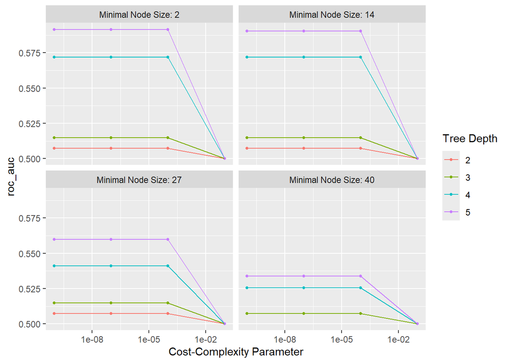

```r
bestPlot_weapon_carrying_tree <-
  autoplot(weapon_carrying_tree_tune)

bestPlot_weapon_carrying_tree
```

```r
best_weapon_carrying_tree <- select_best(
  weapon_carrying_tree_tune,
  metric = "roc_auc")

best_weapon_carrying_tree
```

```
# A tibble: 1 × 4
  cost_complexity tree_depth min_n .config
            <dbl>      <int> <int> <chr>
1    0.0000000001          5     2 Preprocessor1_Model13
```

Now we’ll create our final workflow with the best hyperparameters.

```r
weapon_carrying_tree_final_wf <- finalize_workflow(weapon_carrying_tree_wf, best_weapon_carrying_tree)
weapon_carrying_tree_final_wf
```

```
══ Workflow ════════════════════════════════════════════════════════════════════
Preprocessor: Recipe
Model: decision_tree()

── Preprocessor ────────────────────────────────────────────────────────────────
2 Recipe Steps

• step_impute_mode()
• step_impute_mean()

── Model ───────────────────────────────────────────────────────────────────────
Decision Tree Model Specification (classification)

Main Arguments:
  cost_complexity = 1e-10
  tree_depth = 5
  min_n = 2

Computational engine: rpart
```

## Fitting the Final Model

We’ll fit our final model on the training data. This process is also time-consuming, so we’ll save the results.

```r
weapon_carrying_tree_fit <- fit(
  weapon_carrying_tree_final_wf,
  analysis_train)

weapon_carrying_tree_fit

saveRDS(weapon_carrying_tree_fit, here("models","model_outputs", "tree_fit.rds"))
```

## Model Evaluation

Let’s examine the model’s predictions on the training data.

```r
tree_pred <-
  augment(weapon_carrying_tree_fit, analysis_train) |>
  select(WeaponCarryingSchool, .pred_class, .pred_1, .pred_0)

tree_pred
```

```
# A tibble: 14,696 × 4
   WeaponCarryingSchool .pred_class .pred_1 .pred_0
   <fct>                <fct>         <dbl>   <dbl>
 1 0                    0            0.0396   0.960
 2 0                    0            0.0396   0.960
 3 0                    0            0.0396   0.960
 4 0                    0            0.0396   0.960
 5 0                    0            0.0396   0.960
 6 0                    0            0.0396   0.960
 7 0                    0            0.0396   0.960
 8 0                    0            0.0396   0.960
 9 0                    0            0.0396   0.960
10 0                    0            0.0396   0.960
# ℹ 14,686 more rows
```

We can visualize the model’s performance using an ROC curve.

```r
roc_tree <-
  tree_pred |>
  roc_curve(truth = WeaponCarryingSchool,
           .pred_1,
           event_level = "second") |>
  autoplot()

roc_tree

saveRDS(roc_tree, here("models","roc_graphs","tree.rds"))

tree_pred |>
  roc_auc(truth = WeaponCarryingSchool,
           .pred_1,
           event_level = "second")
```

[output not shown]

[figure not shown]

## Cross-Validation Results

We’ll fit the model on each cross-validation fold to get a more robust estimate of its performance.

```r
fit_resamples(weapon_carrying_tree_final_wf, resamples = analysis_folds) |>
  collect_metrics()
```

```
# A tibble: 3 × 6
  .metric     .estimator   mean     n std_err .config
  <chr>       <chr>       <dbl> <int>   <dbl> <chr>
1 accuracy    binary     0.955      5 0.00141 Preprocessor1_Model1
2 brier_class binary     0.0412     5 0.00135 Preprocessor1_Model1
3 roc_auc     binary     0.592      5 0.0226  Preprocessor1_Model1
```

## Tree Graph

Finally, let’s create a graphical representation of the tree.

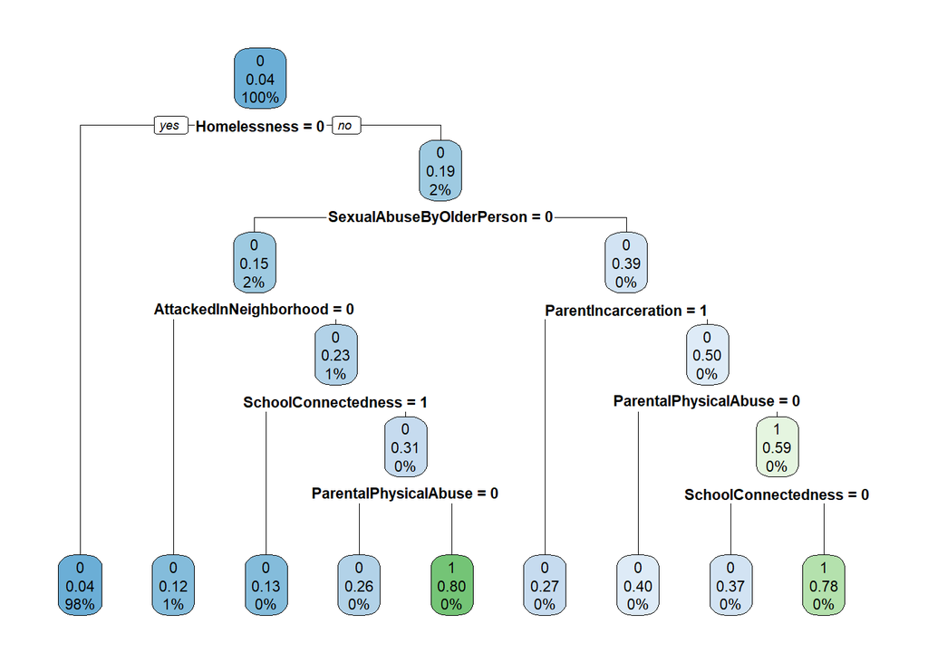

```r
weapon_carrying_tree_fit |>
  extract_fit_engine() |>
  rpart.plot::rpart.plot(roundint=FALSE)
```